# How to maximize the profit of ‘Prosper’?

# by JINSOO KIM

## 1. Data wrangling.

Before Analysis I found Duplicated data Number of rows in dataset.

```
## # A tibble: 1 x 1
##        n
##    <int>
## 1 113937
```

Number of rows in ListingKey which is unique key for each listing, same value as the ‘key’ used in the listing object in the API.

```
## # A tibble: 1 x 1
##        n
##    <int>
## 1 113066
```

These are examples of duplicated ListingKey.

```
## # A tibble: 5 x 2
##   ListingKey                  n
##   <fct>                   <int>
## 1 17A93590655669644DB4C06     6
## 2 349D3587495831350F0F648     4
## 3 47C1359638497431975670B     4
## 4 8474358854651984137201C     4
## 5 DE8535960513435199406CE     4
```

I found that for each ListingKey, only the ProsperScores are different.

```
##                    ListingKey ListingNumber           ListingCreationDate
## 13079 17A93590655669644DB4C06        951186 2013-10-02 17:20:16.550000000
## 14889 17A93590655669644DB4C06        951186 2013-10-02 17:20:16.550000000
## 20570 17A93590655669644DB4C06        951186 2013-10-02 17:20:16.550000000
## 31451 17A93590655669644DB4C06        951186 2013-10-02 17:20:16.550000000
## 42751 17A93590655669644DB4C06        951186 2013-10-02 17:20:16.550000000
## 42752 17A93590655669644DB4C06        951186 2013-10-02 17:20:16.550000000
##       CreditGrade Term LoanStatus ClosedDate BorrowerAPR BorrowerRate
## 13079               60    Current                0.16662       0.1435
## 14889               60    Current                0.16662       0.1435
## 20570               60    Current                0.16662       0.1435
## 31451               60    Current                0.16662       0.1435
## 42751               60    Current                0.16662       0.1435
## 42752               60    Current                0.16662       0.1435
##       LenderYield EstimatedEffectiveYield EstimatedLoss EstimatedReturn
```

[output cut: 174 more lines]

I decide to delete 827 duplicated ListingKeys because there are not info that which one is valuable.

```
## # A tibble: 1 x 1
##        n
##    <int>
## 1 112239
```

## 2. Univariate Plots Section

2-1. Let’s see the distribution of Income Range

```
##
##             $0      $1-24,999      $100,000+ $25,000-49,999 $50,000-74,999
##            621           7209          17046          31703          30463
## $75,000-99,999  Not displayed   Not employed
##          16650           7741            806
```

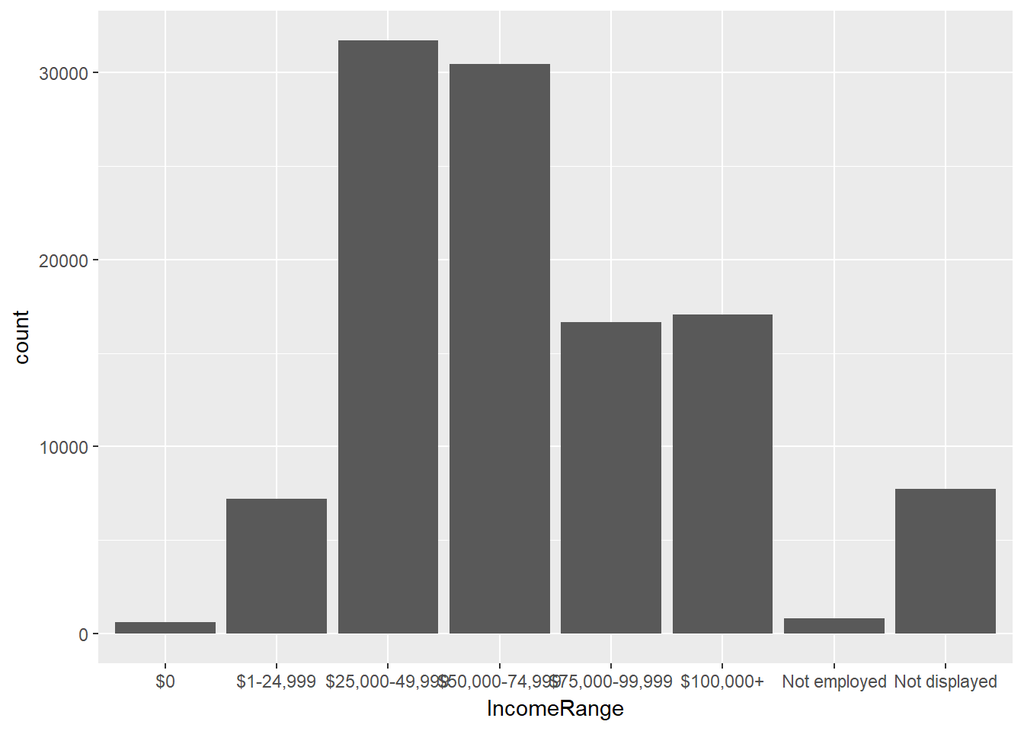

2-2. Occupation distribution

[figure not shown]

2-3. Reasons to borrow money

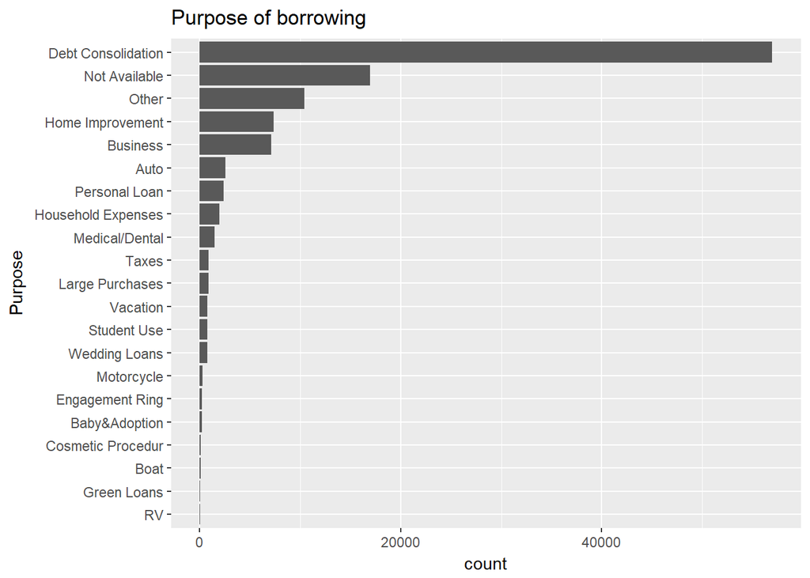

2-4. Loan distribtion by states

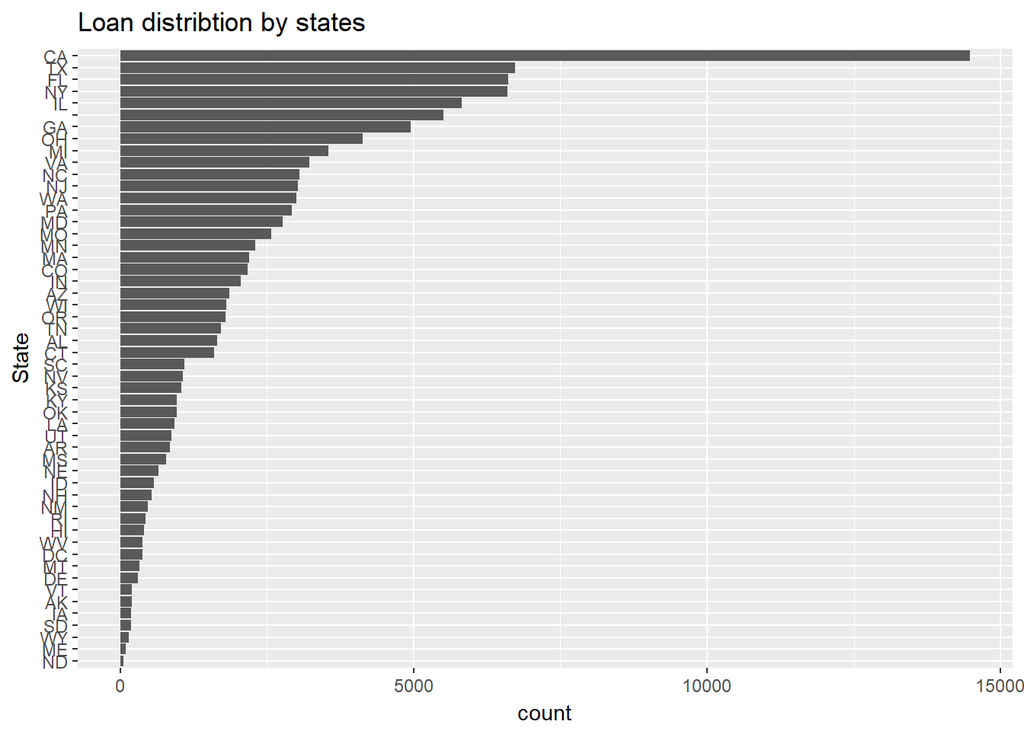

2-5. LenderYield distribution

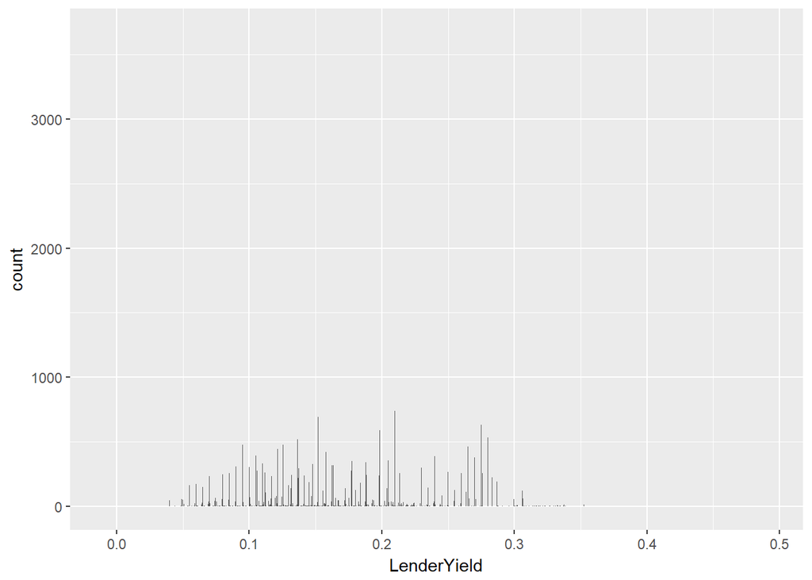

2-6. Loan creation date distribution

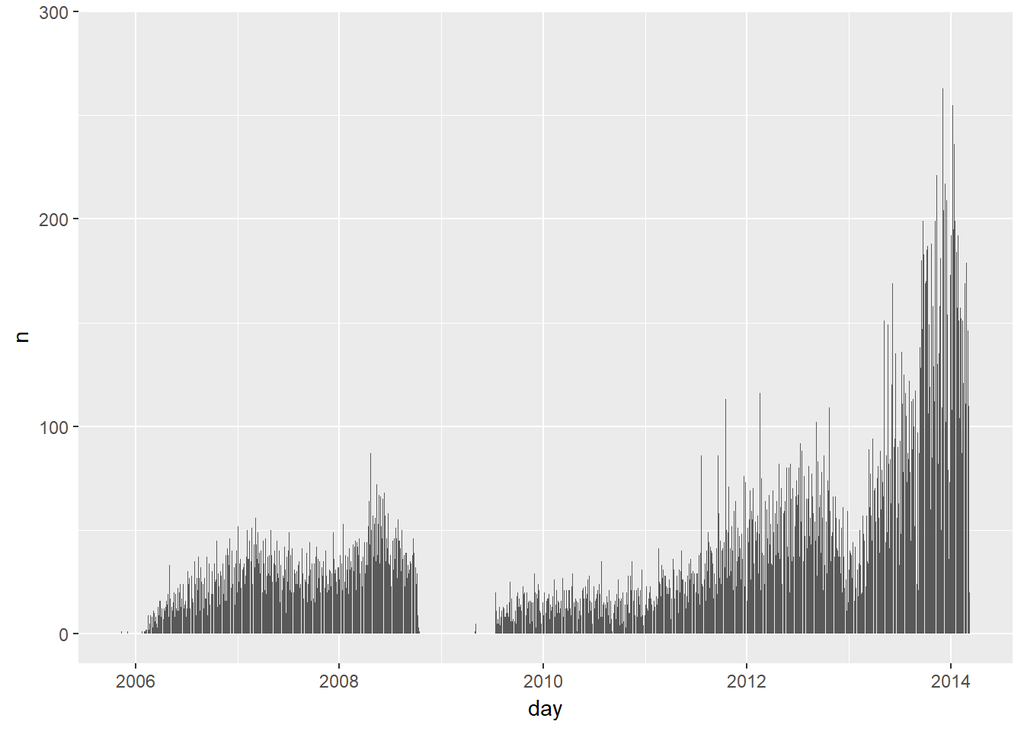

1. Variables (ProsperRating (Alpha) & ProsperScore) are only available from July 2009.
2. To predict, using recent data only is better than with a big pausing term. Plus, the shape and number of loans are quite different.

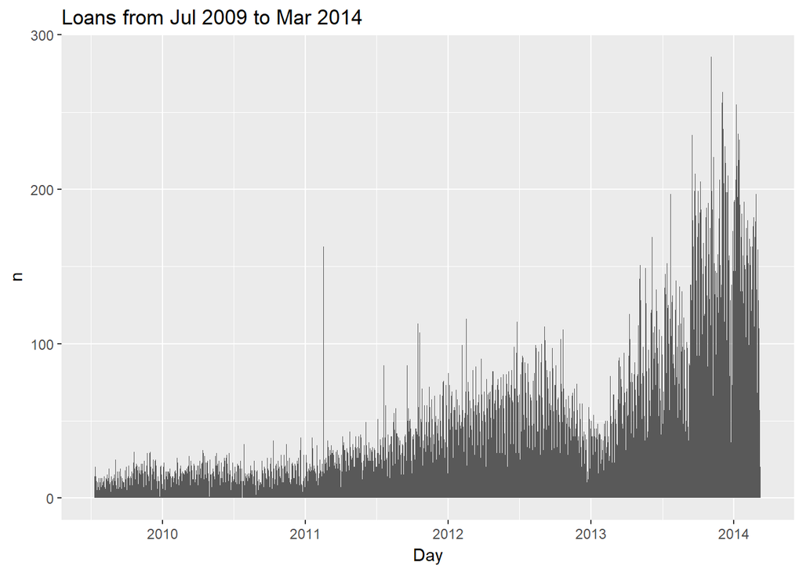

2-7. Prosper score distribution

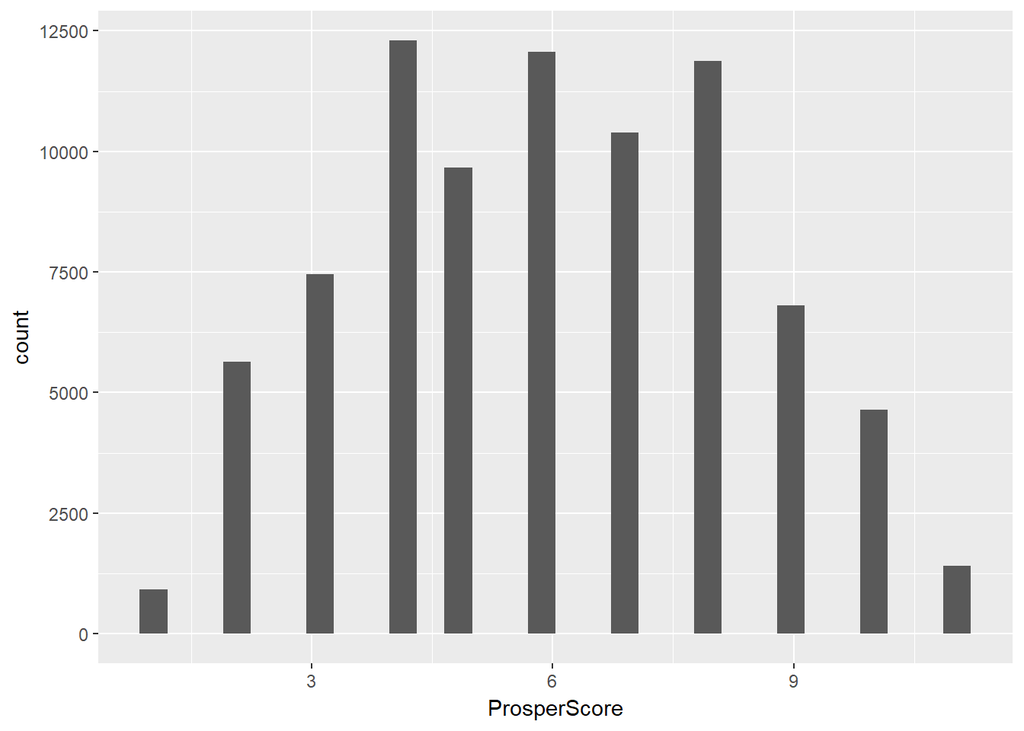

2-8. Prosper Rating distribution

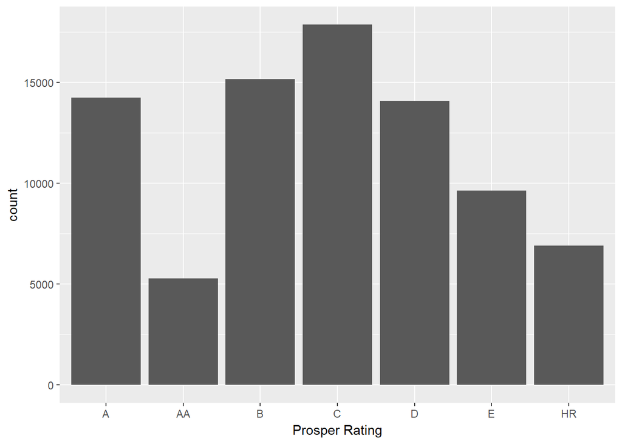

## Univariate Analysis

### Structure of this dataset

> This dataset consists of 81 variables and 113,937 loans. Some of ListingKeys are duplicated. Therefore I removed them. 81 variables are quite a lot. Some variables are related, others are not. I chose 8 variables to make better profits.

### Main features of this dataset?

> 1. Which kind of people borrow the most.  
>    Before starting, I had an assumiption. High borrow rate group has more chances to grow loans. Incomes range, Occupations, Borrowing reason, Region, Loan Creation date, Prosper Score & Rating are all to measure first feature.
> 2. Big benefit. If LenderYield is small, the amount of loans is not much. I thought LenderYield variable can measure the benefit.

### Extra variables that could support my investigation

> **OnTimeProsperPayments** , **ProsperPaymentsLessThanOneMonthLate**

By checking above variables, I would be able to tell people can pay back or not.